# 머신러닝을 위한 기본적인 데이터 준비

데이터 분석을 위한 데이터 준비 단계

1. 데이터 불러오기
2. 데이터 살펴보기
3. 데이터 분할: train, test, validation ...
4. 데이터 변환: scale, normalize ...

### 1. 기본적인 데이터 분석을 위한 toy data set 불러오기 - boston

http://scikit-learn.org/stable/modules/generated/sklearn.datasets.load_boston.html#sklearn.datasets.load_boston  
실제 데이터 분석에서는 파일, 데이터베이스 등 다양한 소스로부터 데이터를 불러 온다.  
여기서는 sklearn이 제공하는 데이터셋을 불러오고, 그 내용을 파악하는 방법을 설명함으로써, sklearn을 이용한 머신러닝의 공부를 원활하게 하는 것이 목표이다.  
다양한 파일, 데이터베이스 등의 소스로부터 가져오는 것은 다음 기회에 학습한다.

```python
from sklearn.datasets import load_boston
boston = load_boston()
print(type(boston))
```

```
<class 'sklearn.utils.Bunch'>
```

sklearn.utils.Bunch: 파이썬의 dictionary와 유사한 객체, 키와 값으로 구성되어 있음  
keys()를 이용해 어떤 key들이 있는지 확인하고, key값을 사용해 data를 불러올 수 있음

```python
print(boston.keys())
```

```
dict_keys(['data', 'target', 'feature_names', 'DESCR', 'filename'])
```

```python
print(boston.DESCR) #boston['DESCR'] 도 가능, 데이터 셋에 대한 설명
```

```
.. _boston_dataset:

Boston house prices dataset
---------------------------

**Data Set Characteristics:**

    :Number of Instances: 506

    :Number of Attributes: 13 numeric/categorical predictive. Median Value (attribute 14) is usually the target.

    :Attribute Information (in order):
        - CRIM     per capita crime rate by town
        - ZN       proportion of residential land zoned for lots over 25,000 sq.ft.
        - INDUS    proportion of non-retail business acres per town
        - CHAS     Charles River dummy variable (= 1 if tract bounds river; 0 otherwise)
        - NOX      nitric oxides concentration (parts per 10 million)
        - RM       average number of rooms per dwelling
        - AGE      proportion of owner-occupied units built prior to 1940
        - DIS      weighted distances to five Boston employment centres
        - RAD      index of accessibility to radial highways
        - TAX      full-value property-tax rate per $10,000
        - PTRATIO  pupil-teacher ratio by town
        - B        1000(Bk - 0.63)^2 where Bk is the proportion of blacks by town
        - LSTAT    % lower status of the population
        - MEDV     Median value of owner-occupied homes in $1000's

    :Missing Attribute Values: None

    :Creator: Harrison, D. and Rubinfeld, D.L.

This is a copy of UCI ML housing dataset.
https://archive.ics.uci.edu/ml/machine-learning-databases/housing/


This dataset was taken from the StatLib library which is maintained at Carnegie Mellon University.

The Boston house-price data of Harrison, D. and Rubinfeld, D.L. 'Hedonic
prices and the demand for clean air', J. Environ. Economics & Management,
vol.5, 81-102, 1978.   Used in Belsley, Kuh & Welsch, 'Regression diagnostics
...', Wiley, 1980.   N.B. Various transformations are used in the table on
pages 244-261 of the latter.

The Boston house-price data has been used in many machine learning papers that address regression
problems.

.. topic:: References

   - Belsley, Kuh & Welsch, 'Regression diagnostics: Identifying Influential Data and Sources of Collinearity', Wiley, 1980. 244-261.
   - Quinlan,R. (1993). Combining Instance-Based and Model-Based Learning. In Proceedings on the Tenth International Conference of Machine Learning, 236-243, University of Massachusetts, Amherst. Morgan Kaufmann.
```

```python
print(type(boston.data), type(boston.target)) #data는 예측에 사용하는 변수들, target은 예측할 대상
print(boston.data.shape, boston.target.shape) #data, target 각각의 shape을 살펴봄
print(boston.data[:5]) #data의 실제 모양과 값을 확인
print(boston.target[:5]) #target의 실제 모양과 값을 확인
print(boston.feature_names) #data에 있는 변수값들의 변수명 확인
```

```
<class 'numpy.ndarray'> <class 'numpy.ndarray'>
(506, 13) (506,)
[[6.3200e-03 1.8000e+01 2.3100e+00 0.0000e+00 5.3800e-01 6.5750e+00
  6.5200e+01 4.0900e+00 1.0000e+00 2.9600e+02 1.5300e+01 3.9690e+02
  4.9800e+00]
 [2.7310e-02 0.0000e+00 7.0700e+00 0.0000e+00 4.6900e-01 6.4210e+00
  7.8900e+01 4.9671e+00 2.0000e+00 2.4200e+02 1.7800e+01 3.9690e+02
  9.1400e+00]
 [2.7290e-02 0.0000e+00 7.0700e+00 0.0000e+00 4.6900e-01 7.1850e+00
  6.1100e+01 4.9671e+00 2.0000e+00 2.4200e+02 1.7800e+01 3.9283e+02
  4.0300e+00]
 [3.2370e-02 0.0000e+00 2.1800e+00 0.0000e+00 4.5800e-01 6.9980e+00
  4.5800e+01 6.0622e+00 3.0000e+00 2.2200e+02 1.8700e+01 3.9463e+02
  2.9400e+00]
 [6.9050e-02 0.0000e+00 2.1800e+00 0.0000e+00 4.5800e-01 7.1470e+00
  5.4200e+01 6.0622e+00 3.0000e+00 2.2200e+02 1.8700e+01 3.9690e+02
  5.3300e+00]]
[24.  21.6 34.7 33.4 36.2]
['CRIM' 'ZN' 'INDUS' 'CHAS' 'NOX' 'RM' 'AGE' 'DIS' 'RAD' 'TAX' 'PTRATIO'
 'B' 'LSTAT']
```

### 2. 데이터 살펴보기

목적: 데이터가 어떤 모양인지와 데이터 간의 연관성 등을 파악한다.  
이를 위해서는 그래프가 필수적임: matplotlib를 사용한다.  
https://matplotlib.org/tutorials/index.html

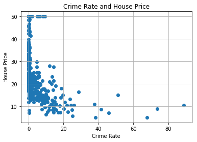

```python
%matplotlib inline
import matplotlib.pyplot as plt

x = boston.data[:,0]
y = boston.target

#간략 버전
#plt.scatter(x, y)
#plt.show()

fig, ax = plt.subplots() #전체 그림판과 각각의 subplot을 반환
ax.scatter(x, y)

ax.set(xlabel='Crime Rate', ylabel='House Price',
       title='Crime Rate and House Price') #개별적인 subplot에 대해 설정
ax.grid()
plt.show()
#fig.savefig("test.png") #전체 그림판을 저장
```

```python
# ravel()의 역할 이해
import numpy as np
a = np.array([[1, 2], [3, 4], [5, 6]])
print(a)
print(a.ravel())
```

```
[[1 2]
 [3 4]
 [5 6]]
[1 2 3 4 5 6]
```

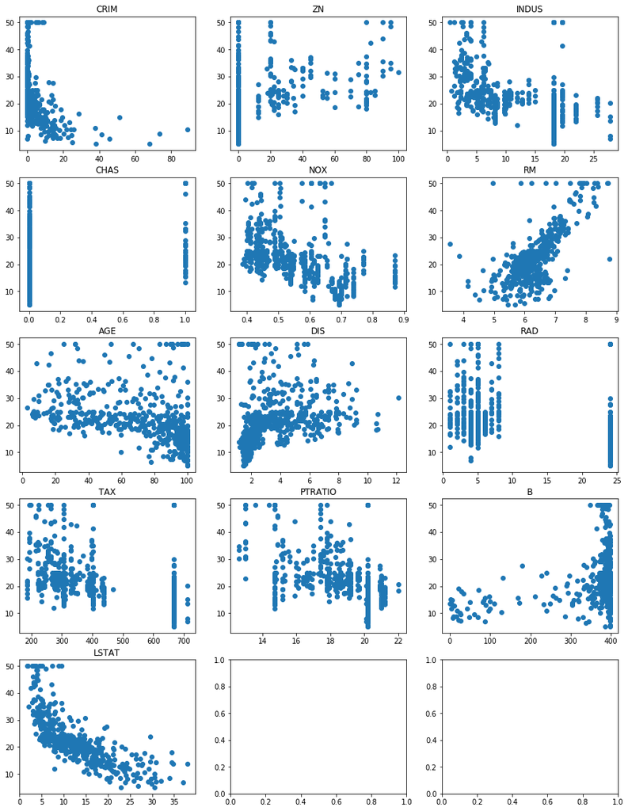

```python
fig, axes = plt.subplots(5, 3, figsize=(15, 20))
y = boston.target

for i, ax in enumerate(axes.ravel()): #나누어진 각 subplot에 대해, ravel()은 ndarray를 flat하게 바꿈
    if i < boston.data.shape[1]: #그려야 할 변수는 13개인데 subplot의 수는 3*5 = 15개
        # 즉 그려야 할 변수에 대해서만 그래프를 그림
        x = boston.data[:,i] # 대상이 되는 변수만 x에 골라냄

        ax.set_title(boston.feature_names[i]) # subplot의 제목을 변수의 이름으로
        ax.scatter(x, y)
plt.show()
```

### 3. 데이터 분할

목적: 학습용 데이터와 검증용 데이터로 분리해서 올바르게 학습되었는지 확인한다.  
http://scikit-learn.org/stable/modules/generated/sklearn.model_selection.train_test_split.html

일반적으로 머신러닝은 학습용 데이터에 과적합되는 경향이 있다.  
즉, 학습용 데이터에서만 예측이 잘 되고 일반화는 잘 안되는 경향이 있다.  
극단적인 예를 들어, 키를 이용해서 몸무게를 예측하는 상황에서 만일 데이터에 키가 크고 마른 사람들과 키가 작고 뚱뚱한 사람들만 우연히 들어와있다면 이것으로 학습을 해봤자 일반적인 상황에는 잘 안 맞을 수 있다.  
그러나, 학습에 사용한 데이터에 대해서는 여전히 잘 맞는 것처럼 보인다.  
이와 같은 상황을 방지하기 위해서 데이터를 학습용과 검증용으로 나누어 사용하게 되고, 이 때 두 데이터 셋에는 값이 랜덤하게 들어가는 것이 중요하다.

또한 data(독립변수)와 target(종속변수)는 반드시 짝을 맞춰서 나누어지고, 랜덤하게 섞여야 한다는 것을 기억해야 한다. 만일 짝이 틀려지면 전혀 의미없는 데이터가 된다.

```python
from sklearn.model_selection import train_test_split
X_train, X_test, Y_train, Y_test = train_test_split(boston.data, boston.target, test_size=0.2) #test_size를 명시하지 않으면 0.25
print(X_train.shape, Y_train.shape)
print(X_test.shape, Y_test.shape)
```

```
(404, 13) (404,)
(102, 13) (102,)
```

### 4. 데이터 변환 (표준화: Standardize features)

목적: 데이터 간 분포의 편차가 클 때, 이를 조정한다.  
일반적으로는 feature 별(column별)로 독립적으로 수행하나, 상황에 따라 같은 sample 내(row별)에서 수행할 수도 있다.  
상황에 따라서 수행여부 선택: 에러가 발생하거나 예측률을 향상시키고자 할 때 수행, 본 수업에서는 특별한 언급이 없으면 하지 않는다.  
더 정확히 이야기하면, 사용하는 알고리즘에 따라 데이터에 대한 민감도가 다르다.  
예를 들어 SVM 같은 경우 각 변수 별로 분포의 편차가 크면 성능이 떨어지는 경향이 있으므로 가급적 표준화를 하는 것이 좋다.  
실제로 결과를 비교해 보면 표준화를 하는 쪽이 성능이 우수한 경우가 많다.

주의사항: train과 test set 전체에 대해 fit을 하고 나눠서 사용한다고 생각할 수도 있으나, 원칙적으로 반드시 train data에 대해서만 fit을 하고 이 scaler를 이용해 test data를 transform하는 것이 정확하다.  
http://scikit-learn.org/stable/modules/generated/sklearn.preprocessing.StandardScaler.html

```python
from sklearn.preprocessing import StandardScaler
scaler = StandardScaler()
print(scaler.fit(X_train)) #X_train set을 대상으로 평균, 표준편차를 계산
print('scaler mean:', scaler.mean_)
print('scaler variance:', scaler.var_)

print('--- train data before scaling ---')
print(X_train[:5])
scaled_X_train = scaler.transform(X_train) #계산된 평균, 표준편차를 이용하여 train set의 값을 변환
print('--- train data after scaling ---')
print(scaled_X_train[:5])

scaled_X_test = scaler.transform(X_test) #계산된 평균, 표준편차를 이용하여 test set의 값을 변환,
# train set과 동일한 값으로 변환하는 것에 유의
print('--- test data after scaling ---')
print(scaled_X_test[:5])
```

```
StandardScaler(copy=True, with_mean=True, with_std=True)
scaler mean: [3.40637262e+00 1.16361386e+01 1.11342327e+01 7.17821782e-02
 5.55781436e-01 6.31022277e+00 6.90272277e+01 3.79433317e+00
 9.43811881e+00 4.04279703e+02 1.83683168e+01 3.59416535e+02
 1.25766584e+01]
scaler variance: [6.77396871e+01 5.35220328e+02 4.71364021e+01 6.66294971e-02
 1.37496826e-02 4.74462718e-01 7.76662575e+02 4.48741454e+00
 7.45630024e+01 2.76999094e+04 4.85340212e+00 7.51446194e+03
 4.83902148e+01]
--- train data before scaling ---
[[6.89900e-02 0.00000e+00 2.56500e+01 0.00000e+00 5.81000e-01 5.87000e+00
  6.97000e+01 2.25770e+00 2.00000e+00 1.88000e+02 1.91000e+01 3.89150e+02
  1.43700e+01]
 [3.56868e+00 0.00000e+00 1.81000e+01 0.00000e+00 5.80000e-01 6.43700e+00
  7.50000e+01 2.89650e+00 2.40000e+01 6.66000e+02 2.02000e+01 3.93370e+02
  1.43600e+01]
 [1.36420e-01 0.00000e+00 1.05900e+01 0.00000e+00 4.89000e-01 5.89100e+00
  2.23000e+01 3.94540e+00 4.00000e+00 2.77000e+02 1.86000e+01 3.96900e+02
  1.08700e+01]
 [9.06000e-03 9.00000e+01 2.97000e+00 0.00000e+00 4.00000e-01 7.08800e+00
  2.08000e+01 7.30730e+00 1.00000e+00 2.85000e+02 1.53000e+01 3.94720e+02
  7.85000e+00]
 [3.30600e-02 0.00000e+00 5.19000e+00 0.00000e+00 5.15000e-01 6.05900e+00
  3.73000e+01 4.81220e+00 5.00000e+00 2.24000e+02 2.02000e+01 3.96140e+02
  8.51000e+00]]
--- train data after scaling ---
[[-0.40549398 -0.50297058  2.1142765  -0.27808871  0.21506712 -0.63910389
   0.02414081 -0.72539091 -0.86139316 -1.29950092  0.33212375  0.34300195
   0.25780079]
 [ 0.01972044 -0.50297058  1.0145904  -0.27808871  0.20653899  0.18405186
   0.21431855 -0.42383571  1.68638135  1.57252743  0.83143292  0.3916834
   0.25636325]
 [-0.39730119 -0.50297058 -0.07926955 -0.27808871 -0.56952057 -0.60861664
  -1.67669406  0.07131338 -0.62977729 -0.76475087  0.10516503  0.43240508
  -0.2453397 ]
 [-0.41277551  3.38726776 -1.18915142 -0.27808871 -1.32852388  1.1291566
  -1.73051795  1.65834908 -0.97720109 -0.71668345 -1.3927625   0.40725685
  -0.67947807]
 [-0.40985949 -0.50297058 -0.86580001 -0.27808871 -0.34778927 -0.36471864
  -1.13845518  0.48049942 -0.51396936 -1.08319753  0.83143292  0.42363781
  -0.58460015]]
--- test data after scaling ---
[[-0.19107216 -0.50297058  1.23015801  3.59597476  0.41974217  2.16572309
   1.04679469 -0.82782904 -0.51396936 -0.007689   -1.66511296  0.34830845
  -1.53194181]
 [-0.38325937 -0.50297058 -0.07926955 -0.27808871 -0.56952057 -0.76540821
   0.13178859  0.26462404 -0.62977729 -0.76475087  0.10516503  0.34623199
   0.78825462]
 [ 1.24802099 -0.50297058  1.0145904  -0.27808871  1.57103933 -0.54473859
   0.67720399 -0.93173057  1.68638135  1.57252743  0.83143292 -3.3507896
   3.08257526]
 [ 0.11450427 -0.50297058  1.0145904  -0.27808871  0.20653899 -0.20792707
   0.53726188 -0.35921     1.68638135  1.57252743  0.83143292  0.43240508
   0.53380929]
 [-0.3905652  -0.50297058 -0.54681821 -0.27808871 -0.53540806  0.17534121
  -1.94940176  0.76548513 -0.51396936 -0.70466659  0.55908246  0.39525952
  -1.07767783]]
```